# Airlines Performance in Terms of Delay and Cancellation

## Investigation Overview

My investigation aims to look at the leading causes of flight delays and cancellations and how they affect flight performance. I also wanted to discover the correlation between the delay and some factors that cause the flight delay.

## Dataset Overview

The original dataset folder contains datasets about flights for each year from 1987 to 2008. However, for this project, I used only datasets from 2005 to 2008 due to the magnificent size of the datasets. The combined datasets constitute over 28.74 million flight records in the US from 2005 to 2008. It has much detailed information, such as specific information about times of flights, delays and cancellations, airline companies, and destinations.

## The most prevalent flight cancellations reasons.

In the dataset we have four unique fligh cancellations codes.  
A = carrier  
B = weather  
C = NAS (national aviation system)  
D = security  
The following chart will show the popularity of each cancellation code.

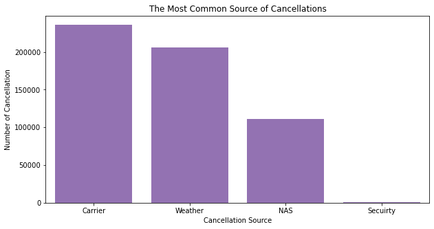

The bar chart above tells us that there are mainly three cancellations sources that caused almost most of the cancellations. Carrier had the highest number of cancellations, with over 200k cancellations. Weather comes next, with about 200,000 flight cancellations. After that comes NAS, which means cancellations attributed to the national aviation system that can be duo many different circumstances, including non-extreme weather conditions, airport operations, heavy traffic volume, and air traffic control, with slightly over 100,000 flight cancellations. Finally, the chart shows that security had very few cancellation instances.

## Flight Cancellations per Months and Days of Week.

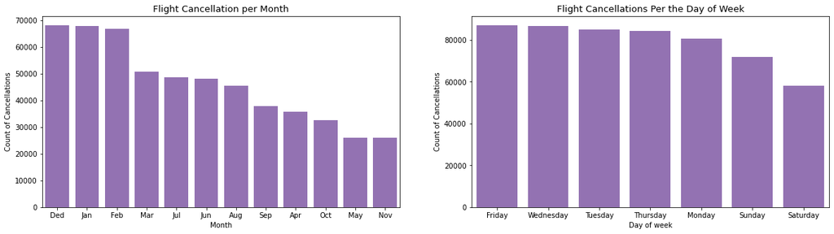

We can obviously see that December, January, and February have the highest flight cancellations numbers. Those are winter months in the US, so it might be related to the weather, but it needs further analysis to confirm.  
Regarding the chart of the cancellations per day of the week, it's kind of expected that Friday would have the highest number of flight cancellations, but in general there are not much of differences between the other days

## Flight Cancellations related to weather per Months

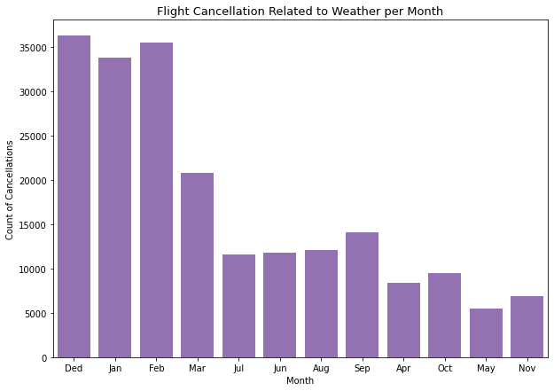

As expected, weather played as major factor for cancellation during winter months

## Which airports had the most flight cancellation number?

In the following chart, I will plot a bar chart with the top 10 airports regarding flight cancellations.

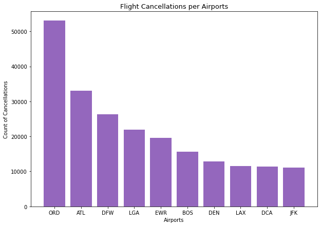

## Flight Cancellation Reasons per Each Month

Now, let's put each month in a chart with all cancellation reasons to see if the weather indeed plays as a major factor during the winter months

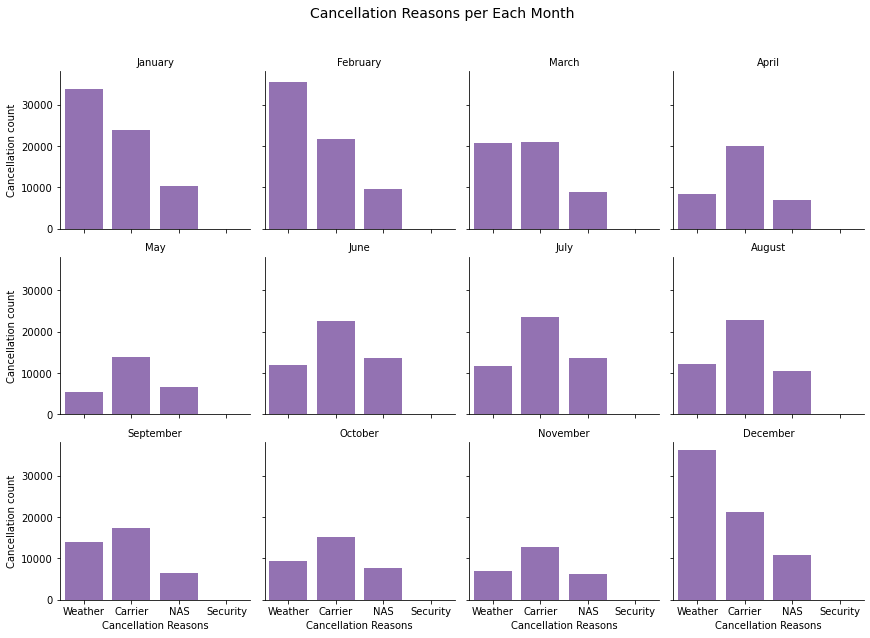

It's clear that winter months recorded higher numbers of flight cancellations related to the weather more than the other months.

## Which airline companies had the highest number of cancellation regarding each cancellation reason?

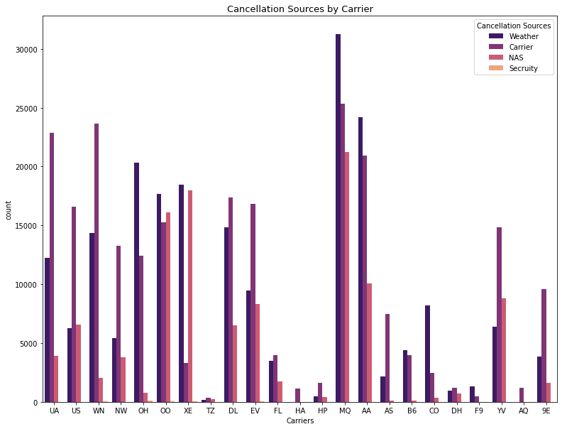

It's obvious from the above chart that Envoy Air airline (MQ)) had canceled more flights than all the other airlines, and it also had been subject to more flight cancellations related to weather than the others. American Airlines and United Airlines had high flight cancellation numbers, but they had been less subject to weather and NAS cancellations than Envoy Air airline. Tsaradia airlines (TZ) had a noticeable few flight cancellations, but that is not surprising since it is a domestic airline company and it only has 10 destinations

## What is the average delay time per airline company?

In the following cells, I will group the data by the airline companies and calculate the average departure delay for each carrier. Then, I will need to sort the values in descending order. After that, I will create a bar chart using the seaborn barplot() function to show the delay per each airline company in descending order. I will also use random samples of 2 million records.

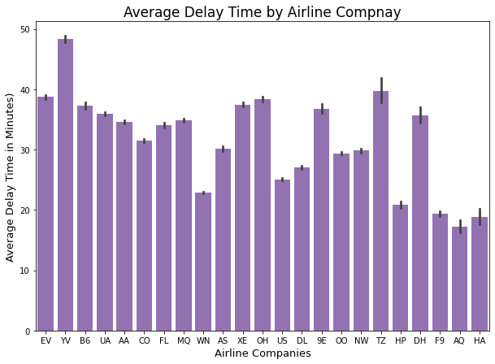

The above chart shows that YV (Mesa Airlines) had the greatest average of the departure delay time. The chart also highlights that 9 Air (AQ) airlines had the smallest average of departure delays.

## What is the average arrival delay time per destination?

Here, I will limit the amount of data to include only data about the top 10 destination airports. The reason I am doing this is that we have so many destinations in the dataset. I will also use random samples of 1 million records.

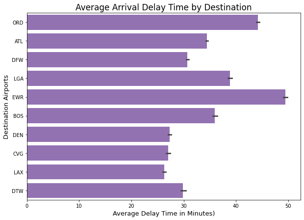

### What is the correlation coefficients between Arrival Delay and the reasons of dealys listed in the dataset

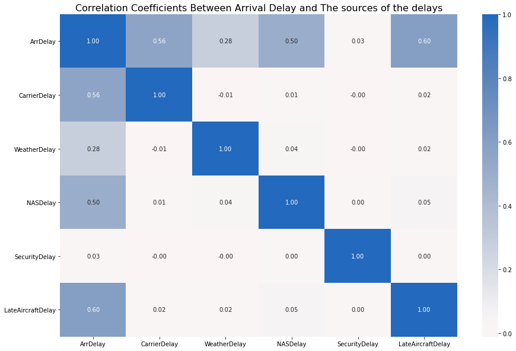